## Enunciado.

En una emocionante competencia de cubos Rubik, participantes de Chile, Argentina, Colombia, Uruguay, Perú y Ecuador demostraron su destreza en resolver tres tipos de cubos: 2x2x2, 3x3x3 y Megaminx.

Hipótesis nula ($H_0$): No existen diferencias significativas en los tiempos de resolución del cubo 3x3x3 entre los participantes de Argentina, Perú y Colombia.

Hipótesis alternativa ($H_1$): Al menos un país presenta un tiempo de resolución significativamente diferente en comparación con los demás.

#### Comprobación de condiciones

**1.Escala de intervalos iguales**

La primera condición se verifica, ya que, por ejemplo, si una persona demora 472 segundos en armar un cubo de 2x2x2 y otra persona se demora 473 segundos en armar el mismo tipo de cubo, la diferencia de 1 segundo es independiente de que en otra instancia dos personas tarden 753 y 754 segundos en resolver un Megaminx. En ambos casos, la diferencia observada refleja únicamente el desempeño individual y no una relación entre las mediciones, lo que asegura la independencia de las observaciones necesaria para el ANOVA.

Se comprueba mediante los gráficos QQ la condición de normalidad de la población de origen.

**2. Condición de independencia de los datos.**

El tiempo que toma armar un cubo, por ejemplo el de 2x2x2,no influye en el tiempo que toma armar cualquiera de los otros dos tipos de cubo. Además,omo dice el enunciado “Para ello usaron una muestra aleatoria de los datos de la competencia” se utiliza la aleatoriedad para la muestra de datos

**3.Condición de normalidad.**

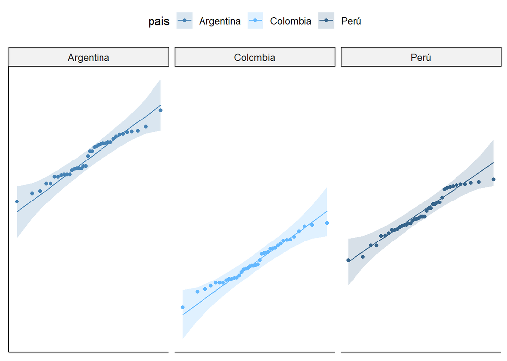

```r
library(dplyr)
library(tidyr)
library(ggpubr)

# Cargar datos
datos <- read.csv("EP05 Datos.csv", sep = ";")
datos$tiempo <- as.numeric(gsub(",", ".", datos$tiempo))

# Filtrar 3x3x3 y países de interés
datos_filtrados <- datos %>%
  filter(tipo == "3x3x3", pais %in% c("Argentina", "Perú", "Colombia")) %>%
  droplevels()

# Verificación gráfica de la condición de normalidad con QQ-plots
g1 <- ggqqplot(datos_filtrados, x = "tiempo", y = "pais",
               color = "pais", alpha = 0.7,
               palette = c("steelblue", "steelblue1", "steelblue4"))

g1 <- g1 + facet_wrap(~ pais) +
  rremove("x.ticks") + rremove("x.text") +
  rremove("y.ticks") + rremove("y.text") +
  rremove("axis.title")

print(g1)
```

**4 Homocedasticidad**

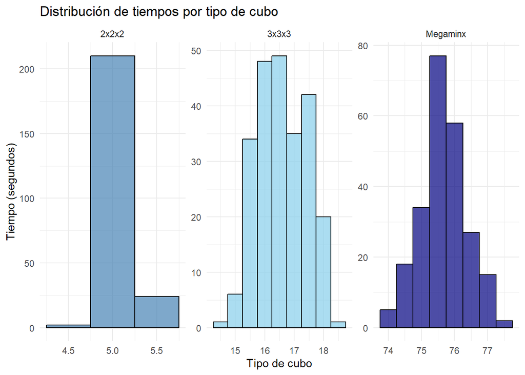

```r
ggplot(datos, aes(x = tiempo, fill = tipo)) +
  geom_histogram(alpha = 0.7, binwidth = 0.5, color = "black") +
  scale_fill_manual(values = c("steelblue", "skyblue", "navy")) +
  labs(title = "Distribución de tiempos por tipo de cubo",
       x = "Tipo de cubo",
       y = "Tiempo (segundos)") +
  theme_minimal() +
  theme(legend.position = "none") + facet_wrap(~ tipo, scales = "free")
```

En relación al gráfico, se concluye que efectivamente la relación entre la mayor y la menor varianza de grupos es muy grande. Por lo tanto, no se cumple la condición de homocedasticidad.

##### Procedimiento ANOVA

Independiente del resultado anterior, se procede a realizar una prueba ANOVA ómnibus a los datos.

```r
# Modelo ANOVA
modelo <- aov(tiempo ~ pais, data = datos_filtrados)

# Resumen ANOVA
summary(modelo)
```

```
##              Df Sum Sq Mean Sq F value Pr(>F)
## pais          2  44.72  22.358   240.8 <2e-16 ***
## Residuals   116  10.77   0.093
## ---
## Signif. codes:  0 '***' 0.001 '**' 0.01 '*' 0.05 '.' 0.1 ' ' 1
```

Ya que el p-valor es mucho menor a 0.05, podemos concluir que existe al menos un país cuyo tiempo promedio de resolución de cubos de Rubik es significativamente diferente del de los demás. En consecuencia, necesitamos contar con un procedimiento post-hoc para medias independientes paraque permita determinar cuáles países poseen diferentes tiempos entre sí.

```r
# Análisis post-hoc
TukeyHSD(modelo)
```

```
##   Tukey multiple comparisons of means
##     95% family-wise confidence level
##
## Fit: aov(formula = tiempo ~ pais, data = datos_filtrados)
##
## $pais
##                          diff        lwr        upr p adj
## Colombia-Argentina -1.5138947 -1.6777789 -1.3500106     0
## Perú-Argentina     -0.8209435 -0.9838511 -0.6580360     0
## Perú-Colombia       0.6929512  0.5321712  0.8537312     0
```

Al analizar los datos de la prueba HSD de Tukey, podemos notar que el p-valor ajustado de los 3 pares es de 0, lo cual sugiere que los resultados son extremadamente significativos. Podemos ver que la diferencia entre las medias de los tiempos de Colombia y Argentina es de -1.51 aprox., lo cual sugiere que Colombia es aprox. 1.51 más rápida que Argentina. Así mismo, podemos verificar ue Perú es aprox. 0.82 segundos más rápido que Argentina, y que Colombia es aprox. 0.69 segundos más rápida que Perú.

Esto sugiere que no solo existen diferencias en el tiempo de resolución de cubos 3x3x3 entre participantes de Argentina, Perú y Colombia, si no que todos los países difieren significativamente entre sí, siendo Colombia el país con participantes más rápidos (para cubos de 3x3x3), seguida de Perú y por último Argentina.